# Introduction

A few weeks before this project began, a young father in Khan Younis described on X (formerly Twitter) how late-night explosions had forced his children to sleep in a narrow hallway for safety. His brief post conveyed cautious relief at rumors of a possible ceasefire, even as he struggled with the aftermath of repeated strikes. Across the border, an Israeli parent wrote a desperate plea upon hearing that a loved one might be among the hostages taken on October 7, 2023. Both tweets, though limited in length, revealed profound anxiety and hope—one family praying for an end to air raids, the other anguished over relatives still unaccounted for.

These snapshots hint at a conflict that escalated in October 2023, when Hamas attacked Israeli territory and took hostages, triggering military responses in Gaza. The hostilities continued for more than a year, leading to a fragile ceasefire arrangement by January 2025. This report analyzes how people on X/Twitter discussed the ceasefire at that pivotal moment. Although tweets are confined to a few hundred characters, they hold genuine fears, hopes, and questions from those living in or closely watching the region. The sections below outline our methods and findings, always mindful that social media posts reflect real individuals shaped by a long and difficult conflict.

# Data Collection

This data collection, undertaken by the author on January 16, 2025 in the morning hours of the Coordinated Universal Time (UTC), merged technical rigor with empathy for the individuals affected by the conflict. A 15-hour window was divided into five consecutive three-hour blocks/segments, producing five CSV files that capture the fluctuating nature of early discussions of the ceasefire. Each segment contributed up to 1,450 tweets, bringing the total to 7,250 records as follows:

- [Window 1] collected up to 1450 tweets from 2025-01-16T07:47:49Z to 2025-01-16T10:47:49Z...
- [Window 2] collected up to 1450 tweets from 2025-01-16T04:47:49Z to 2025-01-16T07:47:49Z...
- [Window 3] collected up to 1450 tweets from 2025-01-16T01:47:49Z to 2025-01-16T04:47:49Z...
- [Window 4] collected up to 1450 tweets from 2025-01-15T22:47:49Z to 2025-01-16T01:47:49Z...
- [Window 5] collected up to 1450 tweets from 2025-01-15T19:47:49Z to 2025-01-15T22:47:49Z...

**Environment Setup and Search Query.** Python libraries such as `os`, `requests`, `csv`, and `datetime` managed the fetching, parsing, and storage of tweets. The query targeted English-language references to “Gaza” and “ceasefire,” along with variations like “ceasefire agreement,” “Israel,” and “Hamas.” This broad approach was chosen so that nuances in phrasing—whether capturing Israeli families hoping to be reunited with loved ones, Palestinian parents yearning for a cessation of hostilities, or individuals worldwide celebrating the ceasefire—would not be lost in overly restrictive filters.

**Fetching Tweets and Preserving Context.** The Twitter API’s “Recent Search” endpoint supported expansions to capture retweets and quotes. This step was vital for understanding how narratives emerge and spread. Some tweets came from media outlets reporting on the status of the ceasefire, while others were direct appeals from residents on either side who had witnessed or endured violence. Gathering original tweet metrics (likes, retweets, quotes) added further insight into which messages garnered the most attention.

**Merging User and Original Tweet Details.** Paginated results often lacked complete user information in a single response. To keep user data consistent, each page’s user objects were compiled into a dictionary keyed by user ID, ensuring that important details such as username and follower count would not be fragmented across different sections of the dataset. Referenced tweets underwent similar consolidation, linking any retweet or quote to its original text and metrics. This provided a fuller picture of how conversations could shift from expressions of grief or fear to hope or even skepticism about the ceasefire’s prospects.

**Storing Results and Managing Rate Limits.** Five CSV files housed the referencing tweets, their original tweets, and key user metrics. Consistent field structures allowed for easier processing in subsequent analysis, whether the goal is to discern sentiment, identify influential accounts, or track misinformation narratives. Twitter’s Basic plan rate-limit constraints necessitated brief pauses after each request, along with longer waits if a “Too Many Requests” error was encountered. These measures ensured a continuous flow of data without jeopardizing completeness during high-traffic periods, particularly when discussions of hostage situations or updates on ceasefire negotiations spiked.

**Why Geo-Data Was Not Collected.** Some readers may wonder if location data would strengthen this analysis by showing who is tweeting from Gaza or Israel. Twitter’s v2 API under the Basic plan rarely includes precise geolocation, since most users do not opt in to share their coordinates. Collecting geo expansions or advanced fields would generate heavier payloads, likely pushing the rate-limit boundaries. Fewer than 1% of tweets typically include exact coordinates, so the potential return did not justify the added complexity for this study. Text-based geographic references can be parsed through advanced natural language processing (NLP), although that challenge falls outside the scope of this study.

## Important Note

Prolonged conflicts spark a wide range of perspectives—some describing life in Gaza with limited resources and frequent danger, others spotlighting Israeli families coping with the sudden disappearance of loved ones. This project analyzes how social media users discuss the ceasefire, not to endorse or discredit any perspective, but rather to illuminate public discourse under challenging circumstances. Each tweet represents a personal lens shaped by unique experiences. Although this report identifies general trends in how people talk about the ceasefire, it cannot capture the full sweep of human realities during war. The findings should be read with an awareness that no single project can encapsulate the depth of a conflict spanning many years.

# Data Preprocessing

Consolidating the tweets from five three-hour windows demanded more than a routine file merge. This stage carefully unified all five CSV files, removed duplicates, addressed missing data, and prepared text for deeper analysis, ensuring that every tweet—original or retweeted—remained faithfully represented. The resulting “master” dataset not only enabled robust storytelling but also preserved the diverse perspectives that emerged around the ceasefire.

Python libraries such as `pandas`, `numpy`, and `re` formed the backbone of our workflow, much as they did during data collection. In addition, `nltk` provided advanced natural language processing features,i.e. tokenization, stopword removal, and beyond. This setup offered a flexible framework for refining thousands of tweets, many of which captured profound personal experiences or urgent updates. By the end, our dataset was primed for the in-depth explorations that followed, blending quantitative rigor with an appreciation for the human realities behind each post.

## Consolidating All CSV Files

The project's five CSVs (`tweets_period_1.csv` to `tweets_period_5.csv`) were combined into a single DataFrame. Each file corresponds to one three-hour window, offering a time-stamped glimpse into how discussions and reactions evolved in near-real time.

```
Reading tweets_period_1.csv...
Reading tweets_period_2.csv...
Reading tweets_period_3.csv...
Reading tweets_period_4.csv...
Reading tweets_period_5.csv...

Combined DataFrame shape: (7250, 22)
```

The result was a single dataset of around 7,250 tweets, each row corresponding to an original post or a retweet/quote. Multiple windows sometimes overlapped, so the combined DataFrame was scrutinized to prevent overcounting.

## Removing Duplicates

A check was performed to eliminate repeat entries. The uniqueness of each tweet is determined by its `tweet_id`. This prevents skewing subsequent analyses, i.e. statistical distortion.

```
Rows before deduplication: 7250
Rows after deduplication:  7250
Duplicates removed:        0
```

No duplicates were found, implying each tweet was unique across the five windows.

## Handling Missing Values

Some columns (like `orig_tweet_id`, `orig_text`) remain empty for tweets that are not retweets or quotes. Retaining these as `NaN` helps preserve the distinction between truly original tweets and those referencing other content.

```
Missing value counts for key columns:
```

```
orig_created_at         240
orig_tweet_id           240
orig_lang               240
orig_text               240
orig_author_id          240
orig_author_username    240
reply_count               0
like_count                0
quote_count               0
retweet_count             0
dtype: int64
```

Keeping these 240s rows in these columns as `NaN` (rather than replacing with placeholders) ensures future analyses accurately separate original posts from references.

## Basic Text Cleaning

A preliminary pass of text cleaning removed URLs, standardized text to lowercase, and trimmed extra whitespace. Hashtags and mentions remain intact to preserve contextual cues about who and what might be tagged. This step ensures data is standardized without losing important content signals.

```
Basic text cleaning complete.
```

## Labeling Tweets as Original or Referencing

A `tweet_type` column was introduced so each row reflects whether the content is an independent post (`original`) or a retweet/quote (`retweet_or_quote`). This is valuable for later steps that merge referencing tweets with their original text.

```
Tweet type distribution:
```

```
tweet_type
retweet_or_quote    7010
original             240
Name: count, dtype: int64
```

Most tweets in this dataset are retweets or quotes referencing another post. A total of 240 tweets are original, which matches the missing values observed in the original-tweet columns above, since these posts do not reference or originate from any other tweet.

### Advanced Natural Language Processing (NLP) Preprocessing

Retweets and quotes were assigned their “original” text to a new column, `analysis_text`, giving a more authentic picture of the message being shared. A custom function then applied *tokenization*, *stopword* removal, and punctuation filtering. This unified preprocessing approach ensures that references to the same text—whether posted once or retweeted dozens of times—share a consistent basis for deeper inquiry.

## Creating Derived Features

Author and engagement metrics were consolidated so each row reflects the original tweet’s “vantage point.” Retweets or quotes adopt metrics from the original post, while original tweets keep their own counts. New columns such as `analysis_engagement_score`, `analysis_impact_score`, and `analysis_interaction_rate` quantify both the post’s popularity and the author’s potential reach.

```
Final 'analysis' columns have been created/overwritten for referencing tweets.
```

|  | analysis_retweet_count | analysis_like_count | analysis_author_followers_count | analysis_engagement_score | analysis_impact_score | analysis_interaction_rate |
| --- | --- | --- | --- | --- | --- | --- |
| 0 | 28181 | 134723 | 93133 | 163140 | 15193717620 | 1.751670 |
| 1 | 6515 | 25518 | 2098520 | 32952 | 69150431040 | 0.015702 |
| 2 | 42 | 64 | 324704 | 113 | 36691552 | 0.000348 |
| 3 | 1588 | 2066 | 259532 | 3751 | 973504532 | 0.014453 |
| 4 | 2899 | 16443 | 365652 | 20001 | 7313405652 | 0.054699 |

```
Master cleaned dataset is now saved with shape (7250, 37).
```

This “master” dataset merges technical precision with a sensitivity to the human realities behind each tweet. While the records capture a high-level look at ceasefire conversations—both supportive and critical—they do not offer a comprehensive historical account of the conflict. Instead, they provide a focused snapshot of online dialogue as a ceasefire took shape, setting the stage for further analyses that might explore sentiment, patterns of misinformation, or the interplay of narratives shared by individuals deeply invested in the outcome.

The tweets chronicle complex realities, from residents near conflict zones hoping for normalcy to outside observers forming opinions from afar. Though each post is limited in scope, the combined dataset underscores the human dimension of a ceasefire—one that resonates on both sides and extends well beyond 280 characters of text. This report aims to illuminate public discourse surrounding an event within a broader—and arguably the most polarizing—context in the history of social media, without advocating any particular political stance. It begins with an exploratory analysis in the next section.

# Analysis and Findings

This section steps beyond basic summaries, weaving advanced analytic methods with human context. We explore text trends, network dynamics, and the interplay of time zones—always attentive to the real people whose fleeting posts collectively frame the story of a ceasefire.

## Dataset Examination

The first phase of exploratory analysis revisits the shape of our final dataset: 7,250 tweets gathered within a 15-hour collection window. These tweets were split into five three-hour segments—each capped at 1,450 tweets—providing a series of smaller snapshots of how a ceasefire conversation unfolds across X/Twitter. While this method partially reflects practical constraints, it also illuminates the granular, hour-by-hour shifts in a discourse marked by both anxiety and fleeting hope.

### Distribution of Tweets

```
Total tweets: 7250
Original tweets: 240
Referencing tweets: 7010
```

Only 240 of these posts stand as self-contained messages: personal reflections, official statements, or on-the-ground updates. The remaining 7,010 are retweets and quotes, underscoring social media’s inherent echo effect—especially in times of heightened tension. A lone tweet sharing relief at the first lull in airstrikes, or a post by an Israeli parent still awaiting word on a captive loved one, can ignite countless retweets. Researchers observing this ratio find a vivid demonstration of how a handful of primary accounts and firsthand observations may shape, reinforce, or redirect entire narratives online.

**Why This Ratio Matters?** *Social media magnifies voices in exponential ways. A single post—whether it’s a government announcement or a raw personal account—can spark thousands of reiterations. In the charged context of a ceasefire, amplification may bridge cultural divides by sharing crucial information, or it may sow confusion if rumors propagate faster than facts. Tracing how original tweets become referencing tweets reveals how “small sparks” can flare into “signal flares,” illuminating the digital conversation around Gaza’s fragile peace*.

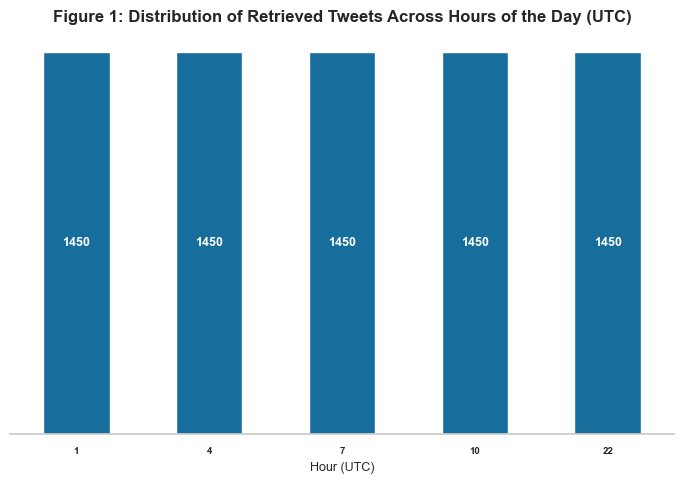

#### The Five Windows

Each three-hour window captured up to 1,450 tweets. These intervals—labeled 1, 4, 7, 10, and 22 UTC—do not necessarily reflect peak or low activity times. Rather, they reflect a methodological cap and Twitter's search behavior: once 1,450 tweets were reached, collection ceased. Observers of the bar chart (**Figure 1**) might mistakenly assume an even posting rate, but the truth is more nuanced.

- **Even Allocation ≠ Even Activity.** Rate limits and data-collection goals, not uniform user behavior, shaped the timing. All segments have attained 1,450 tweets searching within the most recent hour of the data-collection window, hence not stretching to the three-hour mark.
- **Glancing at Quiet vs. Busy Hours.** A lull in one interval can still harbor potent tweets that go on to resonate widely. Meanwhile, a busy block might brim with retweets of just a few originators.

From a sociological lens, these five time slices become small windows into a roiling sea of conflict-driven discourse. The bar chart is thus a record of our sampling more than it is a definitive portrait of when the world tweets about Gaza and the ceasefire.

#### The Global Clock

Parsing tweet hours in UTC hints at an international user base with varying daily cycles. A post at 1 UTC might be a late-night reflection for one region, a mid-day commute update for another, and a dawn scroll for yet another. Geopolitical events—like a late-night briefing in Tel Aviv or a morning press statement in Washington—may unfold while entire continents are asleep, generating delayed ripples of retweets. The mismatch of time zones weaves threads of unpredictability into the conversation, extending each tweet’s lifespan far beyond the moment of posting.

#### Beyond Timestamps: Human Realities

Charts and time blocks only begin to explain these data. Each post—every retweet—stems from someone deciding that a message about the ceasefire needs to be shared. Some families stay offline, anxiously awaiting news about missing loved ones, while advocacy groups or humanitarian organizations broadcast updates that drive sudden spikes. Although 15 hours may seem short, the data already hints at how a single “spark” of information or emotion can course through thousands of screens, connecting people often separated by politics, distance, and circumstance.

**In essence**, *this distribution analysis lays the foundation for deeper dives—covering sentiment, influencer networks, and the interplay of concurrent events. Figures alone cannot reveal why certain posts soar, yet they establish a launching point. The next subsection shows how original tweets and their referencing counterparts form a dynamic feedback loop, evolving hour by hour as the conflict’s narrative unfolds in digital space*.

### Original vs. Referencing Tweets: The Bigger Picture

Out of 7,250 total tweets, 7,010 are retweets or quotes—an imbalance that exemplifies social media’s capacity to escalate a few original voices into a global chorus. In a conflict setting, each post can represent a lifeline of information or an alarm bell. A rumored ceasefire corridor, a heartfelt plea for children’s safety, or an official announcement about hostages can ripple out, magnified by hundreds of retweets.

**Figure 2** visualizes these ripples, mapping retweet hour on the y-axis against original posting hour on the x-axis. Darker cells indicate heavier referencing activity, while lighter cells signal fewer retweets in that hour-to-hour pairing. The result is not just a numeric grid, but a vivid mosaic revealing when the discourse intensifies—and sometimes how it travels across diverse time zones and communities.

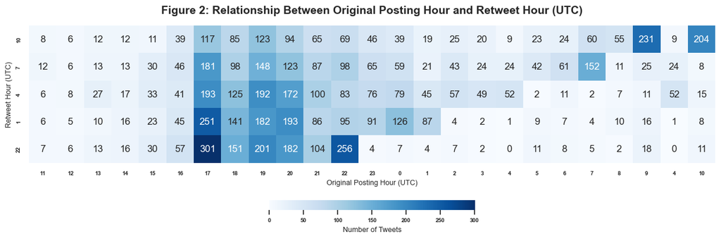

#### Same-Hour Retweets vs. Delayed Waves

Dark cells (diagonal or otherwise) suggest instant or near-instant virality: a tweet posted at 22 UTC might be reposted en masse within that same hour. Off-diagonal clusters reveal delayed engagement—someone in North America encounters an evening bulletin hours later, creating a new retweet spike the following morning. This lag underscores a transnational conversation, where “late-night rumor” for one region becomes “breaking news” for another.

#### What the Dark Cells Reveal

Each patch of darkness suggests an online community rallying around particular information—maybe a rumored agreement on hostages, or a firsthand account of a quiet night after sustained bombardment.

#### Time-Zone Influence and the Seven-Day Window

Activity off the diagonal often emerges from staggered engagement. People in different regions discover a post at different local times, leading to surges several hours later. The seven-day search can revive older tweets if they match “Gaza ceasefire,” but only around 1% of our dataset pre-dates January 15. These edge cases barely shift the overall pattern, which is primarily rooted in a tight 24-hour window of intense activity—particularly near midday and early evening of January 15.

#### Beyond the Heatmap’s Grid

This matrix of hours and retweets may appear technical, yet it conceals deeply personal stakes. One post might capture the relief of an “unexpectedly quiet night,” retweeted widely by people yearning for any good news. Another might recount resumed hostilities, echoing in the retweet columns as fear or grief spreads. The conversation breathes with rapid reactions to breaking developments, sustained echoes when influential users pick up a message hours later, and shared vigilance as communities monitor every sliver of ceasefire progress.

**A Larger Context.** *Such retweet patterns transcend cold metrics, spotlighting how information and emotion flow in a crisis. Each surge of dark cells can represent a wave of renewed concern, a moment of frantic hope, or the steady persistence of those clamoring for resolution. The discussion never halts; it merely shifts across time zones, languages, and emotional tones.*

#### Up Next

Building on this foundation of when and how tweets spread, the next major step is to probe the impact each post generates—an engagement analysis that dissects likes, replies, and other metrics beyond mere retweet timing. This deeper look will help clarify which voices find traction, which narratives endure, and whether certain messages quietly fade or continue reshaping the digital conversation well after they first appear.

## Engagement Analysis

The journey so far has focused on how tweets propagate in time. An equally important aspect involves how deeply each post resonates. Engagement analysis probes which tweets generate fervent attention—be that through likes, retweets, or replies—and asks why certain messages rise above the noise. Figures 3 and 4, alongside the top 10 most impactful tweets, illuminate the powerful interplay between numeric scores and human emotions caught in a polarizing conflict.

### Distribution of Engagement Score

**Figure 3** reveals a distribution that is anything but uniform. The histogram, paired with a boxplot, underscores how most tweets cluster at relatively **low engagement scores**, while a handful spike to extreme values. The vast majority—well over 4,000 tweets—register near the lower end (under 10,000 points). Meanwhile, a thin tail stretches into six-figure territory, indicating a select group of posts attracting massive attention.

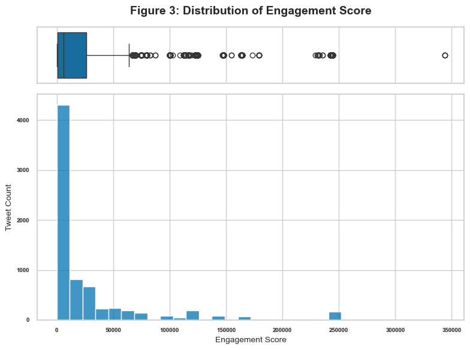

This dramatic skew aligns with the “winner-takes-all” phenomenon often seen on social media. Several factors can fuel such outliers:

- **High-Profile Authors.** Verified accounts, or those with substantial follower bases, can rapidly rack up retweets and likes.
- **Incendiary Content.** Strongly worded messages—especially involving accusations of genocide or impassioned pleas—may captivate or shock readers, driving additional reposts.
- **Timeliness and Relevance.** Tweets surfacing breaking updates or emotional eyewitness stories gain traction more quickly, accumulating engagement faster than routine commentary.

The elongated tail in the boxplot, peppered with discrete outliers, suggests that a small fraction of posts garnered engagement scores tens—or even hundreds—of times above the dataset’s average. Posts hitting such heights can disproportionately shape the public narrative, generating repeated echoes as others chime in or counter them.

### Top 10 Tweets by Analysis Impact Score

```
=== Top 10 Tweets by Analysis Impact Score ===
```

|  | Engagement Score | Impact Score | Interaction Rate | Text |
| --- | --- | --- | --- | --- |
| 5291 | 235442 | 30825553456230 | 0.001798 | @barackobama @joebiden he will be remembered for one thing only. #gaza |
| 5359 | 235442 | 30825553456230 | 0.001798 | @barackobama @joebiden damn you and him , he the worst president, a war criminal. he supported the criminals in israel and gave the cover to commit a genocide in gaza . to the garbage forever |
| 3743 | 233174 | 30528599282892 | 0.001781 | @barackobama @joebiden thank you genocidal joe for killing innocent lives in gaza the world will never forget and forgive you may the wrath of god be with you forever |
| 1948 | 230700 | 30204669264600 | 0.001762 | @barackobama @joebiden netanyahu, biden, and blinken they're killing him, trading hostages for political gain. also, by blood &amp; souls of innocent people in gaza. #ceasefirenow #stoparmingisrael #i… |
| 860 | 229350 | 30027912043800 | 0.001752 | @barackobama @joebiden war criminals in tel aviv are racing against time to commit more massacres and kill children in gaza |
| 2725 | 102986 | 21903243529388 | 0.000484 | @elonmusk i don't seem so. you are supporting the extermination of gaza people: innocent unarmed civilians, children, toddlers. you are supporting the bloody uncivil savage barbarian state of israel l… |
| 7169 | 119435 | 15637191000950 | 0.000912 | @barackobama never forget gaza genocide 2023/2024 - israel and west countries have lost credibility , we don't trust you anymore. mr. obama your quit voice about 14000 children killed is never going t… |
| 410 | 117599 | 15396784078652 | 0.000898 | @barackobama ceasefire happened due to president trump .biden did very little to stop innocent lives lost in revenge attacks from israel. oct 7 the was the darkest day but nethanyahu took it too far ,… |
| 1332 | 117599 | 15396784078652 | 0.000898 | this is such bullshit my god 16 months to get a ceasefire deal and yet is*ael is still currently murdering palestinians in the west bank and gaza yall deadass did nothing but endorse/commit genocide |
| 7140 | 83355 | 3090035200320 | 0.002249 | if by "ceasefire," you mean, attempt to cease for gaza to exist &amp; continue firing. rot in hell eternally bitch. may your blood-stained legacy always haunt you. long live resistance. اتَّقُوا دَعَو… |

A closer look at the top 10 tweets (sorted by impact score, which blends engagement with author reach) offers an unfiltered glimpse into the content fueling that tail:

- **Searing Accusations and Hostile Language.** Many top tweets include harsh rhetoric, labeling specific leaders or entire populations as war criminals or perpetrators of genocide. This hyper-charged tone likely stirs intense reactions—both supportive and outraged—and drives reposts.
- **Notable Political Handles.** The tweets are directed at high-profile figures, such as @barackobama or @joebiden, showing symbolic significance of the U.S. diplomatic efforts, including former President Barack Obama, in the global discourse and the perceptions of global tweeters on the influence they can have in supporting the ceasefire. Tagging influential leaders grabs eyes, boosting engagement.
- **Fervent Claims Tied to Ceasefire.** The table includes repeated mentions of “ceasefire,” often framed as insincere or overshadowed by continuing violence. Posts accusing various parties of brutality or broken promises are retweeted by those who share or contest that viewpoint, amplifying the cycle.

This microcosm of top content demonstrates the dual nature of intense engagement. On one hand, it reveals that a small set of provocative tweets can overshadow calmer, less alarmist messages. On the other, it shows that high engagement does not always stem from constructive dialogue—it can arise from anger, fear, or shock value. For researchers, the presence of vitriolic language indicates a digital environment where extreme statements may outcompete moderate ones, shaping how the ceasefire story unfolds online.

### Correlation Matrix of Engagement-Related Metrics

**Figure 4** presents a correlation matrix among retweets, replies, likes, quotes, author followers, engagement score, impact score, and interaction rate. Each metric is defined in a way that naturally produces the patterns visible in the correlations..

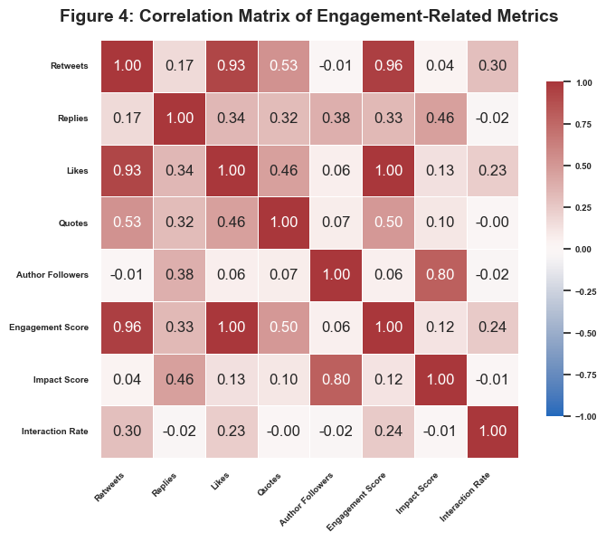

### Synthesizing Key Observations

**Figure 3**’s extreme skew of engagement scores, the table revealing top tweets peppered with inflammatory language, and **Figure 4**’s correlation insights illustrate a conversation driven by tension and amplified by retweets and likes. The war of words includes high-impact posts that accuse leaders of genocide, disparage entire nations, and question the legitimacy of the ceasefire. These claims circulate rapidly, often overshadowing moderate or purely informative content.

A handful of influential tweets—possibly from lesser-known accounts but with searing language—can reach engagement levels on par with more established voices, reflecting a digital environment where sensational or confrontational statements stand out. The correlation matrix confirms that retweets form the backbone of viral reach, and while follower count matters, it does not guarantee a robust interaction rate.

For this ceasefire debate, the data suggests that **emotions run high**. The online sphere sees intense condemnation and suspicion, fueling a cycle where provocative headlines garner immediate reposts. Some readers likely come away with an elevated sense of conflict, while others feel compelled to share or challenge narratives they find offensive or biased.

### Future Directions

Engagement analysis, even when anchored in metrics like retweets and likes, only scratches the surface of how people experience war and peace negotiations in real time. Deeper thematic analysis or sentiment classification might uncover whether these high-impact tweets skew toward fear, anger, or hopeful defiance. Tracking how clusters of influential accounts retweet each other could reveal *echo chambers* that reinforce entrenched opinions.

**Time-Series Considerations.** A fuller time-series analysis—spanning more than our capped hourly windows—could highlight how sentiment and engagement evolve moment by moment or day by day. However, given our sampling constraints (1,450 tweets per three-hour block), a standard time series might not yield much beyond the patterns already uncovered by the bar plot and heatmap under the data examination section. Capturing *all* tweets returned by our search query, without artificial hourly caps, would offer a more complete temporal view. That said, our partial snapshots already show how quickly information surges around key events, mirroring the global and fast-evolving nature of the ceasefire discourse.

The next steps in our exploration involve deeper dives into **textual nuances**— through topic modeling, advanced sentiment analysis, and user network structures. Such methods would illuminate *why* certain tweets soar, *where* clusters form, and *how* they become polarized or bridged by ongoing geopolitical tensions. This layered perspective is vital to understanding how raw engagement numbers intersect with the human realities behind a conflict of this scale.

**In sum**, *the top engagement earners in our dataset illuminate how public discourse can be steered by a fervent minority of tweets—often marked by graphic accusations and impassioned pleas—while thousands of quieter voices linger with minimal attention. The data underscores a simple truth: the loudest posts are not always the most factually grounded, yet they can seize the digital spotlight, shaping perceptions of a conflict that remains painfully real for those on the ground*.

## User-Level Insights & Network Analysis

Our exploration so far has focused on tweet-level data—who posted what and when, and how much engagement each post received. Shifting to a user-level lens can be the most complex step in social media analytics. On one hand, there is a deep desire to understand the individuals shaping online discourse—who they follow, how influential they are, and what they discuss. On the other, ethical debates swirl around privacy and consent: tweets might be publicly visible, yet many authors did not publish their thoughts expecting to be systematically studied.

### Ethical Anonymity

Although it is tempting to highlight the names or handles of “top authors,” we made a **deliberate choice** to preserve anonymity. Scholars and practitioners differ over whether public and viral posts require special permissions to be analyzed or identified. Some argue that once a tweet is public, it is fair game for research. Others caution that repeated exposure—especially of sensitive or polarizing content—can jeopardize user privacy. We err on the side of caution, opting to refer to authors by anonymous IDs instead of their X IDs, handles, and followers count. This approach respects the personal dimension of ceasefire conversations and acknowledges that participants did not explicitly agree to be featured in a dataset.

### Top Authors by Engagement and Impact

The first table, Top Anonymous Authors by Sum Impact, showcases users whose tweets garnered exceptional traction. Two key metrics appear:

- **Sum Engagement.** The total engagement (retweets, replies, likes, quotes) an author accumulated across all their posts.
- **Sum Impact.** A composite measure multiplying that engagement by the user’s follower count, approximating how widely their tweets could have reached.

```
=== Top Anonymous Authors by Sum Impact ===
```

|  | mean_engagement | sum_engagement | mean_impact | sum_impact |
| --- | --- | --- | --- | --- |
| 6 | 189842.625000 | 1518741 | 2.485538e+13 | 198843046662006 |
| 140 | 102986.000000 | 102986 | 2.190324e+13 | 21903243529388 |
| 833 | 38434.316129 | 5957319 | 1.092671e+11 | 16936393081277 |
| 947 | 33119.285714 | 231835 | 1.227748e+12 | 8594238995852 |
| 1235 | 109517.260163 | 13470623 | 4.348775e+10 | 5348993720459 |
| 419 | 29635.518519 | 1600318 | 8.852819e+10 | 4780522405152 |
| 284 | 18889.441065 | 4967923 | 1.576938e+10 | 4147347667961 |
| 386 | 23006.039474 | 5245377 | 1.098702e+10 | 2505040732609 |
| 925 | 38427.090323 | 5956199 | 1.499171e+10 | 2323714382374 |
| 1238 | 37802.705882 | 1927938 | 4.507998e+10 | 2299078785246 |

Meanwhile, `mean_engagement` and `mean_impact` hint at the average resonance per tweet. An author with a sky-high sum might have posted many times, while another might have posted just a few explosive tweets. Combining these measures paints a nuanced picture of who consistently shapes the discourse versus who periodically sets it aflame.

### Most Referenced Original Authors

A second table lists *anonymous original authors* with the highest ref_count (i.e., the number of times their posts were quoted or retweeted). Users like ID 253 (262 referencing tweets) and ID 345 (228 referencing tweets) reflect individuals who, despite potentially lower total impact scores, sparked repeated echoes. It is a reminder that “fame” and “influence” can manifest in varied ways: some authors accumulate sky-high sums of likes or retweets, while others gather repeated references—indicating that their ideas stayed relevant long enough for multiple repost cycles.

```
=== Top Anonymous Authors with Referencing Stats (retweets/quotes) ===
```

|  | ref_count | mean_engagement | sum_engagement | mean_impact | sum_impact |
| --- | --- | --- | --- | --- | --- |
| 253 | 262 | 4945968 | 18877.740458 | 4129019107041 | 1.575961e+10 |
| 345 | 228 | 5245377 | 23006.039474 | 2505040732609 | 1.098702e+10 |
| 649 | 190 | 17657297 | 92933.142105 | 1644634561386 | 8.655971e+09 |
| 766 | 176 | 5783503 | 32860.812500 | 1454754705495 | 8.265652e+09 |
| 195 | 169 | 40747912 | 241111.905325 | 991133678447 | 5.864696e+09 |
| 729 | 155 | 5957319 | 38434.316129 | 16936393081277 | 1.092671e+11 |
| 807 | 155 | 5956199 | 38427.090323 | 2323714382374 | 1.499171e+10 |
| 741 | 130 | 886117 | 6816.284615 | 306227989748 | 2.355600e+09 |
| 1112 | 124 | 9618809 | 77571.040323 | 71390257695 | 5.757279e+08 |
| 1077 | 123 | 13470623 | 109517.260163 | 5348993720459 | 4.348775e+10 |

### Constructing the Network: Nodes and Edges

Diving deeper, we built a *directed graph* with 1,251 nodes and 1,251 edges, where each node represents an anonymous user, and each *edge* represents a referencing relationship (e.g., a retweet or quote). In this structure:

```
Constructed a directed graph with 1251 nodes and 1251 edges.
=== Top In-Degree Authors (Most Referenced) - Anonymous ===
```

|  | in_degree_centrality |
| --- | --- |
| 0 | 0.0008 |
| 831 | 0.0008 |
| 838 | 0.0008 |
| 837 | 0.0008 |
| 836 | 0.0008 |
| 835 | 0.0008 |
| 834 | 0.0008 |
| 833 | 0.0008 |
| 832 | 0.0008 |
| 830 | 0.0008 |

- **Nodes.*** The 1,251 unique authors uncovered in our dataset.
- **Edges.** Links from one author to another when a referencing action occurs (a retweet from user A of user B’s post).

We then calculated *in-degree centrality*—a measure of how many edges point to a given user. Authors with the highest in-degree are those most frequently referenced by others. The table titled *Top In-Degree Authors (Most Referenced)—Anonymous* highlights ID 0, 831, 838, 837, and so forth, all at in_degree_centrality of 0.0008. That uniformity might arise from a relatively small set of referencing relationships or from the fact that, in this network, the top influencers are so close in reference counts that they share similar centrality scores.

**Interpreting In-Degree Centrality.** In-degree centrality effectively captures “popularity,” but in a directed retweet network, it can also signal authoritativeness or salience. A user whose content repeatedly draws reposts from various corners of the platform wields power to shape the conversation. However, the lines between “popular,” “controversial,” and “authoritative” can blur. In a fraught discourse like a Gaza ceasefire, a high in-degree may reflect endorsements, outraged rebuttals, or both.

### Understanding the Limits and Potential of User-Level Analysis

User-level analysis is uniquely powerful yet fraught with pitfalls:

- **Ethical Gray Areas.** Collecting information on individuals—especially in conflict settings—poses risks. Even if posts are public, repeated mentions can lead to harassment or doxxing. Our anonymity stance aims to balance scholarly interest with respect for privacy.
- **Network Complexity.** The conversation can sprawl across multiple retweets and quotes, with different time lags, user motivations, and community norms.
- **Contextual Nuance.** A user’s numeric centrality does not always reveal intent. High in-degree could denote support, anger, or misinformation swirling around a single profile.

### Preliminary Findings

- **Concentrated Influence.** A small roster of authors (IDs like 6, 140, or 833) garnered striking sums of engagement and impact, echoing our earlier findings about “winner-takes-all” patterns.
- **Relevance Over Time.** Some authors rank highly in referencing counts, suggesting that their messages linger in circulation, prompting repeated retweets or quotes.
- **Even Centralities.** The near-identical in-degree centrality values among top authors suggest a clustering effect—these users draw roughly equivalent referencing activity, hinting at a shared level of visibility or repeated back-and-forth among them.

### The Road Ahead

This user-focused lens augments our tweet-level observations: *who* wields the biggest megaphone, *how* are repeated references spread, and *why* might some voices outpace others in shaping the ceasefire narrative? The next iteration could delve into more sophisticated network algorithms—identifying strongly connected subgroups or tracing information diffusion paths. Layering on textual analysis might clarify if high-impact users champion peace, stoke tension, or merely amplify sensational claims. The *next section* will build on these user-level insights by delving into *advanced text analysis*, aiming to uncover deeper sentiment patterns, conversation topics, and the emotional undercurrents fueling each viral post.

**In Sum,** *User-level insights open a window into the social architecture behind each retweet, quote, or direct mention. Yet this analysis also underscores the ethical complexity of mining public data for private inferences. We see powerful voices that dominate via massive engagement or repeated referencing, but the real story lies in the interplay of those influences, local contexts, and personal stakes. By handling these insights with care—balancing curiosity and respect—we approach a fuller understanding of how digital communities interpret and shape a potential ceasefire’s fate.*

## Advanced Text Analysis

Beyond the *who* and *when* of ceasefire tweets lies the *what*, that is the rich tapestry of language and emotion that animates discussions online. This final analytical leap shifts attention from the loud echoes of retweets to the **substance** of the words themselves. A word cloud, sentiment histogram, and two topic-modeling visualizations together reveal both the **raw emotional currents** and the **underlying themes** that power the conversation around a conflict that has gripped the world’s attention.

### A Lexical Snapshop of Ceasefire

**Figure 5** uses Word Cloud, which is generated after text cleaning and tokenization to visualize the most common terms. A glance at the cloud conveys immediacy more powerfully than any table of counts. The biggest words—“gaza,” “ceasefire,” and “israel”—rest at the storm’s center, while terms like “genocide,” “hostage,” and “announcement” cluster around them in swirling fonts. This visual mosaic highlights two central truths:

- **Central Conflicts and Emotions.** Words such as genocide and hostage anchor the deeper unrest beneath the hope for a truce. Some tweets express excitement or relief, others seethe with bitterness or distrust.
- **Multiple Narratives.** Smaller terms like “celebration,” “deal,” “family,” and “recovery” capture glimmers of optimism, as though people are readying themselves for a new era—yet remain unsure how stable that future might be.

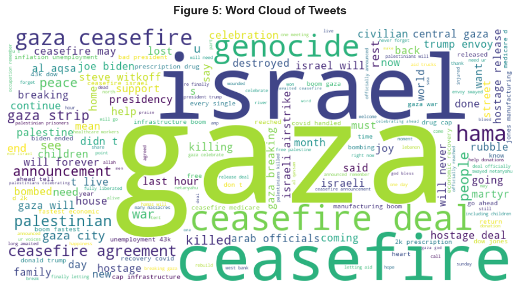

Generative or not, a single word can rarely capture an entire backstory. “Genocide,” for instance, may reflect one user’s fervent accusation, while “celebration” could speak to another user’s private relief. This swirling blend of bold and subtle words is a reminder that social media unites countless parallel realities, each vying to define the meaning of “ceasefire.”

### A Tug-of-War in Emotions

**Figure 6** employs VADER Sentiment, which is a lexicon-based approach assigning sentiment scores to short texts, well-suited for social media. It reveals a distribution of sentiments—**Positive** (3,154), **Negative** (2,905), and **Neutral** (1,191). One might have expected negativity to lead the pack in a conversation rife with accusations and war stories. Instead:

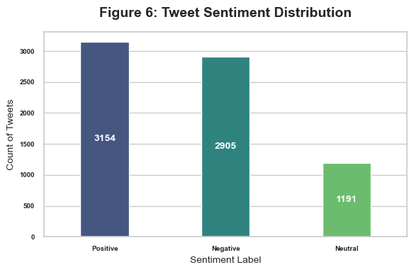

- **Positive Tweets.** Many users express euphoria that bombs may stop falling, or relief at potential hostage releases. In these tweets, “ceasefire” and “celebration” converge—signs of fleeting calm, if not lasting peace.
- **Negative Tweets.** Mistrust and anger remain high. Some are unconvinced that an agreement will hold, others grieve ongoing casualties. This emotional weight reveals a deep psychic toll, overshadowing the official line that “hostilities have ended.”
- **Neutral Tweets.** Often short status updates or re-posts of official statements. Some threads simply read “Breaking news: Ceasefire announced,” never venturing into commentary or advocacy.

Despite the relative surge of positivity, caution and cynicism run deep, suggesting that “hopeful” is not the same as “reassured.” As in many conflicts, words of optimism nestle alongside bitter reminders of unresolved traumas.

### Many Facets of One Conflict

To move beyond raw sentiment, we applied a topic modeling technique such as **Latent Dirichlet Allocation (LDA)**. This algorithm discerns clusters of words that frequently co-occur, spotlighting the major themes swirling around “ceasefire.”

[output not shown]

[interactive chart not shown]

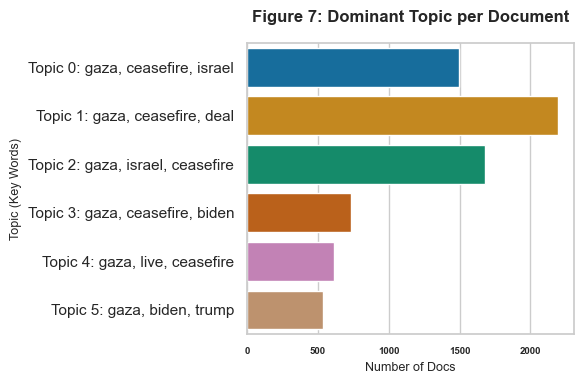

Each bar in **Figure 7** represents a different topic:

- **Topic 0: “gaza, ceasefire, israel”** – The fundamental triad of conflict, shaping many tweets.
- **Topic 1: “gaza, ceasefire, deal”** – Posts that emphasize negotiated settlements, or question their legitimacy.
- **Topic 2: “gaza, israel, ceasefire”** – Echoes Topic 0 but often weaves in “war,” “hamas,” or “amp” (a textual quirk from retweets).
- **Topic 3: “gaza, ceasefire, biden”** – Threads zeroing in on the U.S. President’s role.
- **Topic 4: “gaza, live, ceasefire”** – Real-time reportage, sometimes from individuals claiming to be celebrating the ceasefire or still under bombardment.
- **Topic 5: “gaza, biden, trump”** – Mentions of past/incoming vs. present/outgoing U.S. administrations, reflecting a global vantage on American influence.

### Top Words per Topic

**Figure 8** drills further into each theme’s most characteristic words. Terms like “deal,” “breaking,” and “agreement” define a cluster that fixates on policy announcements or fragile treaties. In contrast, “boom,” “live,” and “president” might shape a more immediate, event-driven focus—tweets reacting to audible shelling or official press statements.

Taken together, these topics reinforce how the ceasefire conversation is multifaceted. Some users highlight diplomacy, others dwell on the ongoing strife, and still others pivot quickly to the roles of Biden, Trump, or other figures outside the immediate arena. That complexity underscores why any simple “ceasefire means peace” narrative struggles to gain universal traction.

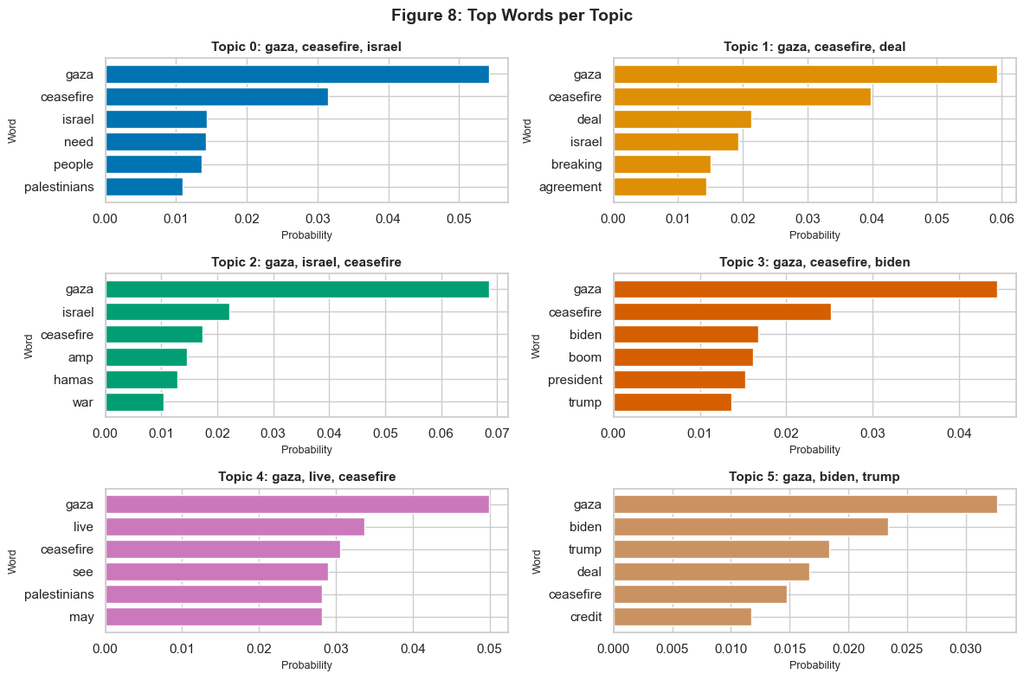

### Confluence of Language, Emotion, and Themes

Advanced text analysis highlights the **human complexity** behind digital chatter. A word cloud underscores the lexicon swirling around the conflict, sentiment scores reveal pockets of guarded optimism and latent rage, and topic clusters confirm that no single storyline dominates. People speak simultaneously of hostages, broken deals, joyous celebrations, and heartbreaking casualties—all under the same broad heading of “ceasefire.”

- **Overlapping Interests.** Many tweets converge on demands for an end to violence but diverge on who is to blame or how trust can be rebuilt.
- **Political Underpinnings.** Leaders like Biden or Trump loom large, revealing that the conversation extends well beyond the immediate geography.
- **Emergent Contradictions.** The same dataset can yield “celebration” and “genocide,” capturing an intense emotional whiplash typical of protracted conflicts.

Refining methods—whether more nuanced sentiment tools or deeper topic analysis—could illuminate sub-threads (e.g., calls for international intervention versus local relief efforts). Another frontier might be comparing these textual patterns to user networks, tying specific sentiments to key influencers.

### Toward a Unified Understanding

In examining the text itself, we glimpse what drives each wave of engagement: moral outrage, cautious hope, policy debates, or raw grief. Far from a uniform voice, the ceasefire conversation is a swirling mosaic of relief and reproach, of breaking news and age-old grievances. Understanding this continuum is critical to any broader reckoning with the ceasefire’s success—or failure—to address the underlying fractures.

The insights gleaned here complement our previous user- and engagement-level findings, setting the stage for a cohesive reflection on how social media shapes perceptions of war and peace.

# Glimpses of a Changing Horizon

When this project began, the ceasefire existed mainly in tweets—fragments of hope or bitter resignation scattered across the internet. As we conclude, the first articles of the ceasefire were implemented yesterday, January 20, with the exchange of Israeli hostages and Palestinian prisoners. Shifts that once seemed purely hypothetical have begun to materialize in the real world, reminding us that social media discussions are not static transcripts of public opinion but windows into a constantly evolving story.

## A Tapestry of Contradictions

Every analysis—tweet-level engagement, user networks, advanced text modeling—uncovered a **chaotic coexistence** of empathy and hostility, celebration and distrust. A single day’s scroll might reveal tearful relief at hostages coming home, sandwiched between allegations of genocide and calls for retribution. It was never one story but many, each vying for space under hashtags like “#ceasefire” and “#gaza.”

- **Empathy vs. Suspicion.** Sentiment data showed a surprising share of “positive” tweets, yet an almost equal surge of negativity—proof that elation and anger often intermingle.
- **Influence vs. Obscurity.** A handful of authors dominated the conversation, yet those with fewer followers sometimes went “viral” through the emotional gravity of their words.
- **Peace vs. Continuation.** Some pinned hopes on a lasting peace, while others braced for the ceasefire’s collapse.

These contradictions echo the real-world tension of an agreement shaped by urgent necessity but still haunted by unaddressed grievances.

## The Power and Limitations of the Data

All insights—whether from correlation matrices or topic distributions—stem from a time-limited cross-section of tweets. Much like a photograph freezes a single instant, our data cannot capture the full evolution of discourse as negotiations intensify or unravel. The stage set by January 20, with tangible steps taken on hostage and prisoner exchanges, marks a shift in reality that may well reshaped today’s tweets. This suggests that social media, for all its immediacy, remains a snapshot of sentiment more than a final verdict.

At the same time, the sheer volume of retweets and quotes revealed how global the conversation has become. Observers on different continents joined the chorus, re-enacting local anxieties, diaspora connections, and longstanding geopolitical debates. The potent mix of raw emotion and political commentary underscores how the lines between eyewitness accounts, advocacy, and rumor can blur at scale.

## Toward the Next Chapter

Ceasefire deals, by nature, exist in precarious balance. The question is not merely whether tweets support or oppose them, but whether this volley of digital expressions reflects genuine forward motion or a temporary standstill. Recent events—hostages returned home, prisoners released—may momentarily tamp down the flames, yet the underlying fracture lines remain visible in the very words people use: “genocide,” “hope,” “ceasefire,” “deal,” “will it last?”

- **Continued Vigilance.** If tensions subside on the ground, discussions might pivot to the practicality of reconstruction, accountability, or long-term coexistence.
- **Collective Responsibility.** Data and discourse alike spotlight how fear and fury can hijack the narrative. But empathy—even if overshadowed—also breaks through. Online communities play a role in shaping which sentiments gain traction.
- **Deeper Dialogues.** Advanced text analytics hinted at more nuanced threads—who calls for humanitarian corridors, who demands justice, who simply yearns to live without bombs overhead.

## A Shared Reflection

Ultimately, the story of this ceasefire in X/Twitter highlights the fragility of our collective reality. People thousands of miles apart weigh in with equal ferocity—some compelled by heartbreak, others by curiosity or ideological fervor. Data can quantify retweets and measure sentiment, yet it cannot fully capture the intangible shift that occurs when a child sleeps safely for the first time in months, or when a hostage sees family again.

Like any snapshot, our findings reflect a moment in time. Tomorrow’s tweets will belong to a renewed conversation—perhaps more measured, perhaps just as inflamed—reshaped by each incremental step toward peace or a relapse into conflict. However it unfolds, this project provides a vital lens into how a digital chorus interprets, contests, and sometimes reimagines events on the ground. And that lens, for all its limitations, can illuminate how tenuous truces and lived experiences coalesce into the global narrative we all inhabit.

# Appendix

## Session Information

```
Python version: 3.11.6 | packaged by conda-forge | (main, Oct  3 2023, 10:37:07) [Clang 15.0.7 ]

Package versions (2 columns):

accessible-pygments==0.0.5                alabaster==0.7.16
anyio==4.8.0                              appnope==0.1.4
argon2-cffi-bindings==21.2.0              argon2-cffi==23.1.0
arrow==1.3.0                              asttokens==3.0.0
async-lru==2.0.4                          attrs==24.3.0
autocommand==2.2.2                        babel==2.16.0
backports.tarfile==1.2.0                  beautifulsoup4==4.12.3
bleach==6.2.0                             blinker==1.9.0
brotli==1.1.0                             cached-property==1.5.2
certifi==2024.12.14                       cffi==1.17.1
charset-normalizer==3.4.1                 click==8.1.8
colorama==0.4.6                           comm==0.2.2
contourpy==1.3.1                          cryptography==43.0.3
cycler==0.12.1                            debugpy==1.8.11
decorator==5.1.1                          defusedxml==0.7.1
docutils==0.20.1                          entrypoints==0.4
exceptiongroup==1.2.2                     executing==2.1.0
fastjsonschema==2.21.1                    fonttools==4.55.3
fqdn==1.5.1                               fst-pso==1.8.1
funcy==2.0                                future==1.0.0
fuzzytm==2.0.5                            gensim==4.3.3
greenlet==3.1.1                           h11==0.14.0
h2==4.1.0                                 hpack==4.0.0
httpcore==1.0.7                           httpx==0.28.1
hyperframe==6.0.1                         idna==3.10
imagesize==1.4.1                          importlib-metadata==8.5.0
importlib-resources==6.5.2                inflect==7.3.1
ipykernel==6.29.5                         ipython-genutils==0.2.0
ipython==8.31.0                           ipywidgets==8.1.5
isoduration==20.11.0                      jaraco.collections==5.1.0
jaraco.context==5.3.0                     jaraco.functools==4.0.1
jaraco.text==3.12.1                       jedi==0.19.2
jinja2==3.1.5                             joblib==1.4.2
json5==0.10.0                             jsonpointer==3.0.0
jsonschema-specifications==2024.10.1      jsonschema==4.23.0
jupyter-book==1.0.3                       jupyter-cache==1.0.1
```

[output cut: 61 more lines]

```
statsmodels==0.14.4                       stdlib-list==0.11.0
tabulate==0.9.0                           terminado==0.18.1
threadpoolctl==3.5.0                      tinycss2==1.4.0
tomli==2.2.1                              tornado==6.4.2
tqdm==4.67.1                              traitlets==5.14.3
tweepy==4.15.0                            typeguard==4.3.0
types-python-dateutil==2.9.0.20241206     typing-extensions==4.12.2
typing-utils==0.1.0                       tzdata==2024.2
uc-micro-py==1.0.3                        unicodedata2==16.0.0
uri-template==1.3.0                       urllib3==2.3.0
wcwidth==0.2.13                           webcolors==24.11.1
webencodings==0.5.1                       websocket-client==1.8.0
wheel==0.45.1                             widgetsnbextension==4.0.13
wordcloud==1.9.4                          wrapt==1.17.2
zipp==3.21.0                              zstandard==0.23.0
```